# Assignment week 02

andresbmendoza

6/15/2021

## Introduction:

This report include the data Analysis from a personal activity monitoring device. This device **collects data at 5 minute intervals through out the day**. The data consists of **two months of data** from an anonymous individual collected during the **months of October and November, 2012** and include the number of steps taken in 5 minute intervals each day. Through the Analysis the R scripts to process the data will be include for more details. The Data, [Activity monitoring data](https://d396qusza40orc.cloudfront.net/repdata%2Fdata%2Factivity.zip), was downloaded and unziped into **Data** Folder from the working directory.

### Load the Data table:

```r
rawData <- read.csv("Data/activity.csv")
```

### Mean total number of steps taken per day

#### Histogram of Dayly Steps:

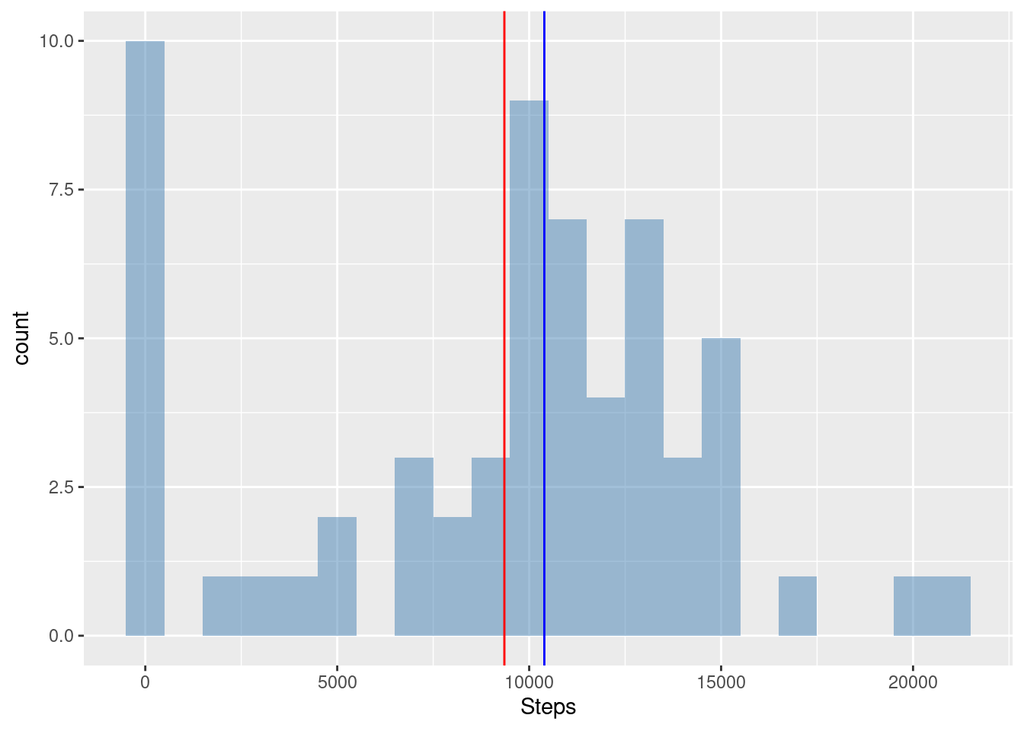

```
## [1] "The Mean in red line above  is:  9354.23 , The Median in blue line above is: 10395"
```

```r
DaylySteps <- rawData %>%
  group_by(Date = date) %>%
  summarize(Steps = sum(steps, na.rm = TRUE))

ggplot(DaylySteps, aes(x= Steps)) +
  geom_histogram(binwidth = 1000, fill = "steelblue", alpha = 0.5) +
  geom_vline(aes(xintercept = mean(x = Steps)), color = "red")+
  geom_vline(aes(xintercept = median(x = Steps)), color = "blue")
```

### Dayly step Pattern by intervals

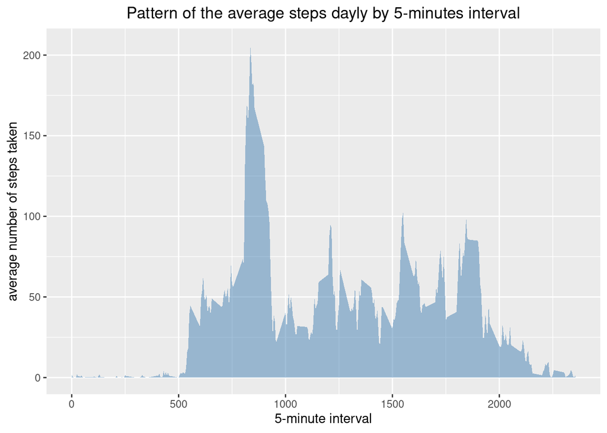

```r
CentralMeasures <- rawData %>%
  group_by(Interval = interval) %>%
  summarize( mean.step = mean(steps, na.rm = TRUE),
             median.step = median(steps, na.rm = TRUE))
ggplot(data=CentralMeasures, aes(x = Interval, y = mean.step)) +
  geom_area(fill = "steelblue", alpha = 0.5) +
  xlab("5-minute interval") +
  ylab("average number of steps taken") +
  ggtitle("Pattern of the average steps dayly by 5-minutes interval") +
  theme(plot.title = element_text(hjust = 0.5))
```

```r
CentralMeasures[which.max(CentralMeasures$median.step),]
```

```
## # A tibble: 1 x 3
##   Interval mean.step median.step
##      <int>     <dbl>       <int>
## 1      845      180.          60
```

### Handleling Misssing Data:

```r
k <- round(sum(is.na(rawData$steps))/length(rawData$steps)*100,2)
print(paste("NAs Values represent the", as.character(k), "% of the total data"))
```

```
## [1] "NAs Values represent the 13.11 % of the total data"
```

About 13.11% of the data are NA values, that is significatively big to biases the central measures as mean, median and mode. One way to impute the missing values is assign it the mean data value.

In order to fill the NAs Values with the Mean, the script below search for each observation into the variable, and replace the NA value with the Average of Steps.

```r
rawData2 <- rawData
mean.val <- mean(rawData2$steps, na.rm = TRUE)

for (k in 1:length(rawData2$steps)) {
  if (is.na(rawData2$steps[k])) rawData2$steps[k] <- mean.val
}
```

### Histogram of the total number of steps taken each day after missing values are imputed

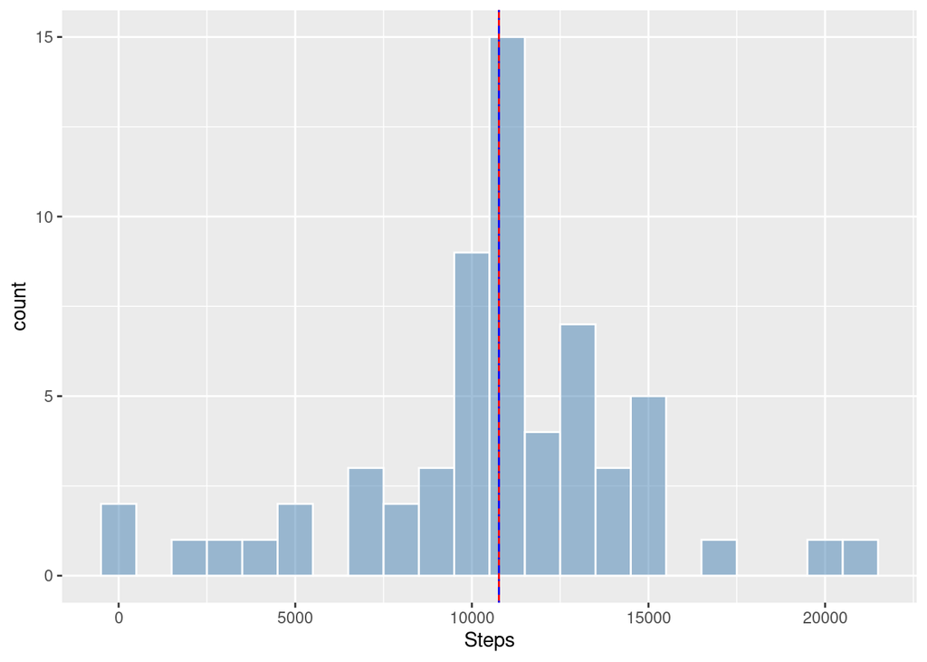

[output not shown]

```r
DaylySteps2 <- rawData2 %>%
  group_by(Date = date) %>%
  summarize(Steps = sum(steps, na.rm = TRUE))

ggplot(DaylySteps2, aes(x= Steps)) +
  geom_histogram(binwidth = 1000,color = "white",
                 fill = "steelblue", alpha = 0.5) +
  geom_vline(aes(xintercept = mean(x = Steps)), color = "red") +
  geom_vline(aes(xintercept = mean(x = Steps)), color = "blue", lty = 4)
```

As could be observed in the Histogram above, the Average of steps increase from 9354.23 to 10766.189; and the Median and Mean are equal. Hence, is possible to conclude that NAs values biased the data.

### Comparing the average number of steps taken per 5-minute interval across weekdays and weekends

```r
is.weekday <- function(date) {
  day <- weekdays(date)
  if (day %in% c("Monday", "Tuesday", "Wednesday", "Thursday", "Friday"))
    return("Weekday")
  else if (day %in% c("Saturday", "Sunday"))
    return("Weekend")
  else
    stop("wrong data date")
}

Data <- rawData2
Data$day <- sapply(as.Date(Data$date), FUN = is.weekday)
Data$day <- as.factor(Data$day)

CentralMeasures2 <- Data %>%
  group_by(interval, day) %>%
  summarize( mean = mean(steps) )
```

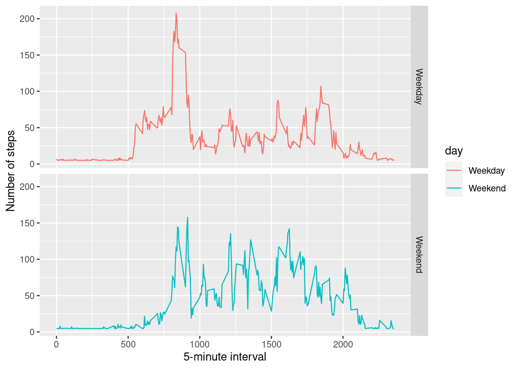

```r
ggplot(CentralMeasures2, aes(interval, mean, color = day)) + geom_line() + facet_grid(day ~ .) +
        xlab("5-minute interval") + ylab("Number of steps")
```